# Midewin_Diversity_Comp.Results.Figures

Marissa Zaricor

Last Updated: 2026-06-05

## Set up and Overview

### Running Title: Management modifies consumer top-down control of plant diversity in grassland restoration

**Background:** Quantifying the independent and interactive effects of management (fire, mow, herbicide, none) and consumers (bison, small mammals, no mammals) on plant community composition and diversity (species richness, Shannon diversity, and evenness) during tallgrass prairie restoration

**Author:** Marissa Zaricor

**Co-authors:** Lauren Sullivan

**Created:** 2025-05-16

**Files:**

1. *Midewin_cover_clean.csv* - contains plant cover, codes, taxon, etc.
2. *Midewin_Aug-Aug_Grazing_Influence_22_24.csv*- bison raster data for total (sum by year) and weighted total (sum of weighted by month/season) but aug year-1 to aug year current. (last updated Jan 2025)

**Last Updated:** 2026-06-05

#### Libraries, Files, Setup

Code for ggplot themes for publications

```r
## set working directory to source file location

cover_clean<- read.csv("Midewin_cover_clean.csv")
cover_clean$herbivory_trt<-factor(cover_clean$herbivory_trt, levels=c("XX", "SX", "SB")) #relevel herbivory


graze_Aug <-read_csv("Midewin_Aug-Aug_Grazing_Influence_22-24.csv")
```

## Species Richness

#### 1. Calculate species richness

```r
#calculate species richness
specRich1<- cover_clean %>%
  filter(live==1) %>%  # remove anything not a plant
  filter(unknown==0) %>%  # remove any unknowns
  filter(code !="" & !is.na(code)) %>%  #remove any empty rows in  code column
  group_by(year, block, plot, management_trt, herbivory_trt, bison_pasture) %>%  #do not include other columns here for now
  summarise(richness=n_distinct(code), .groups = "drop") #counts all distinct species per plot
```

#### 2. Add in bison covariate data

#### 3. Fit the model

```r
#Main results 2024 so remove east and other years
rich_W24<- specRich1 %>% filter(year=="2024")



#fitting the model, guassian
glmm_richW24<-glmmTMB(richness~herbivory_trt*management_trt+(1|block/plot), data = rich_W24, family = gaussian)
summary(glmm_richW24)
```

```
##  Family: gaussian  ( identity )
## Formula:          richness ~ herbivory_trt * management_trt + (1 | block/plot)
## Data: rich_W24
##
##       AIC       BIC    logLik -2*log(L)  df.resid
##     321.9     356.0    -145.9     291.9        57
##
## Random effects:
##
## Conditional model:
##  Groups     Name        Variance Std.Dev.
##  plot:block (Intercept) 1.3530   1.1632
##  block      (Intercept) 0.8449   0.9192
##  Residual               1.3530   1.1632
## Number of obs: 72, groups:  plot:block, 72; block, 24
##
## Dispersion estimate for gaussian family (sigma^2): 1.35
##
## Conditional model:
##                                         Estimate Std. Error z value Pr(>|z|)
## (Intercept)                               6.0000     0.7693   7.799 6.23e-15
## herbivory_trtSX                           0.5000     0.9497   0.526 0.598566
## herbivory_trtSB                           3.3333     0.9497   3.510 0.000449
## management_trtfire                        4.0000     1.0880   3.677 0.000236
## management_trtherbicide                   2.5000     1.0880   2.298 0.021568
## management_trtmow                         4.0000     1.0880   3.677 0.000236
## herbivory_trtSX:management_trtfire       -1.0000     1.3431  -0.745 0.456559
## herbivory_trtSB:management_trtfire       -1.0000     1.3431  -0.745 0.456556
## herbivory_trtSX:management_trtherbicide   1.1667     1.3431   0.869 0.385062
## herbivory_trtSB:management_trtherbicide  -2.6667     1.3431  -1.985 0.047099
## herbivory_trtSX:management_trtmow         0.6667     1.3431   0.496 0.619647
## herbivory_trtSB:management_trtmow        -2.3333     1.3431  -1.737 0.082347
##
## (Intercept)                             ***
## herbivory_trtSX
## herbivory_trtSB                         ***
## management_trtfire                      ***
## management_trtherbicide                 *
## management_trtmow                       ***
## herbivory_trtSX:management_trtfire
## herbivory_trtSB:management_trtfire
## herbivory_trtSX:management_trtherbicide
## herbivory_trtSB:management_trtherbicide *
## herbivory_trtSX:management_trtmow
## herbivory_trtSB:management_trtmow       .
## ---
## Signif. codes:  0 '***' 0.001 '**' 0.01 '*' 0.05 '.' 0.1 ' ' 1
```

```r
#bison covariate is not significant and will be removed from the model

#Results: significnat interaction and main effects

#AIC 321

#use wald chi sqaaure tests to show our approx. entire effects, using type = III because better for our interactions structure
anova_w24<-Anova(glmm_richW24, type="III")
anova_w24
```

```
## Analysis of Deviance Table (Type III Wald chisquare tests)
##
## Response: richness
##                               Chisq Df Pr(>Chisq)
## (Intercept)                  60.829  1  6.225e-15 ***
## herbivory_trt                14.330  2  0.0007731 ***
## management_trt               18.059  3  0.0004278 ***
## herbivory_trt:management_trt 14.197  6  0.0275144 *
## ---
## Signif. codes:  0 '***' 0.001 '**' 0.01 '*' 0.05 '.' 0.1 ' ' 1
```

#### Check assumptions

```
## $uniformity
##
##  Asymptotic one-sample Kolmogorov-Smirnov test
##
## data:  simulationOutput$scaledResiduals
## D = 0.16256, p-value = 0.04451
## alternative hypothesis: two-sided
##
##
## $dispersion
##
##  DHARMa nonparametric dispersion test via sd of residuals fitted vs.
##  simulated
##
## data:  simulationOutput
## dispersion = 1.2844, p-value = 0.088
## alternative hypothesis: two.sided
##
##
## $outliers
##
##  DHARMa outlier test based on exact binomial test with approximate
##  expectations
##
## data:  simulationOutput
## outliers at both margin(s) = 0, observations = 72, p-value = 1
## alternative hypothesis: true probability of success is not equal to 0.007968127
## 95 percent confidence interval:
##  0.00000000 0.04994408
## sample estimates:
## frequency of outliers (expected: 0.00796812749003984 )
##                                                      0
```

```
## # R2 for Mixed Models
##
##   Conditional R2: 0.743
##      Marginal R2: 0.583
```

#### Post-hoc comparisons

```
## management_trt = control:
##  contrast estimate   SE df t.ratio p.value
##  XX - SX    -0.500 0.95 57  -0.526  0.8587
##  XX - SB    -3.333 0.95 57  -3.510  0.0025
##  SX - SB    -2.833 0.95 57  -2.983  0.0115
##
## management_trt = fire:
##  contrast estimate   SE df t.ratio p.value
##  XX - SX     0.500 0.95 57   0.526  0.8587
##  XX - SB    -2.333 0.95 57  -2.457  0.0444
##  SX - SB    -2.833 0.95 57  -2.983  0.0115
##
## management_trt = herbicide:
##  contrast estimate   SE df t.ratio p.value
##  XX - SX    -1.667 0.95 57  -1.755  0.1941
##  XX - SB    -0.667 0.95 57  -0.702  0.7633
##  SX - SB     1.000 0.95 57   1.053  0.5470
##
## management_trt = mow:
##  contrast estimate   SE df t.ratio p.value
##  XX - SX    -1.167 0.95 57  -1.228  0.4415
##  XX - SB    -1.000 0.95 57  -1.053  0.5470
##  SX - SB     0.167 0.95 57   0.175  0.9832
##
## Degrees-of-freedom method: user-specified
## P value adjustment: tukey method for comparing a family of 3 estimates
```

```
## herbivory_trt = XX:
##  contrast             estimate   SE df t.ratio p.value
##  control - fire      -4.000002 1.09 57  -3.677  0.0029
##  control - herbicide -2.500000 1.09 57  -2.298  0.1105
##  control - mow       -4.000003 1.09 57  -3.677  0.0029
##  fire - herbicide     1.500002 1.09 57   1.379  0.5177
##  fire - mow          -0.000001 1.09 57   0.000  1.0000
##  herbicide - mow     -1.500003 1.09 57  -1.379  0.5177
##
## herbivory_trt = SX:
##  contrast             estimate   SE df t.ratio p.value
##  control - fire      -3.000005 1.09 57  -2.757  0.0380
##  control - herbicide -3.666658 1.09 57  -3.370  0.0072
##  control - mow       -4.666669 1.09 57  -4.289  0.0004
##  fire - herbicide    -0.666653 1.09 57  -0.613  0.9276
##  fire - mow          -1.666664 1.09 57  -1.532  0.4255
##  herbicide - mow     -1.000011 1.09 57  -0.919  0.7947
##
## herbivory_trt = SB:
##  contrast             estimate   SE df t.ratio p.value
##  control - fire      -2.999999 1.09 57  -2.757  0.0380
##  control - herbicide  0.166671 1.09 57   0.153  0.9987
##  control - mow       -1.666671 1.09 57  -1.532  0.4255
##  fire - herbicide     3.166670 1.09 57   2.911  0.0257
##  fire - mow           1.333328 1.09 57   1.226  0.6134
##  herbicide - mow     -1.833342 1.09 57  -1.685  0.3409
##
## Degrees-of-freedom method: user-specified
## P value adjustment: tukey method for comparing a family of 4 estimates
```

#### Fig. 2 - Data visualization of Species Richness 2024 West Pasture

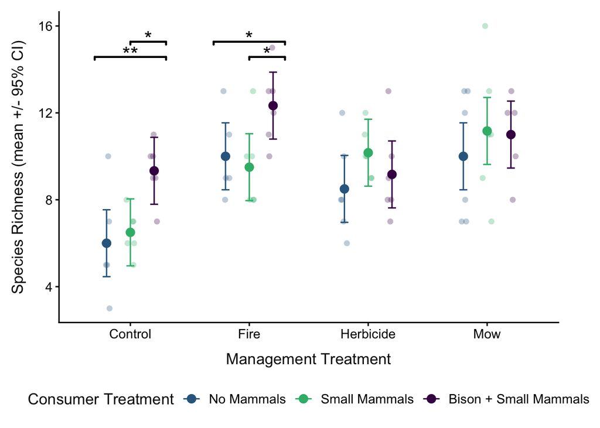

Table: GLMM Spec Rich 2024

```
##                                       Term Estimate Std. Error z value Pr(>|z|)
## 1                              (Intercept)    6.000      0.769   7.799    0.000
## 2                          herbivory_trtSX    0.500      0.950   0.526    0.599
## 3                          herbivory_trtSB    3.333      0.950   3.510    0.000
## 4                       management_trtfire    4.000      1.088   3.677    0.000
## 5                  management_trtherbicide    2.500      1.088   2.298    0.022
## 6                        management_trtmow    4.000      1.088   3.677    0.000
## 7       herbivory_trtSX:management_trtfire   -1.000      1.343  -0.745    0.457
## 8       herbivory_trtSB:management_trtfire   -1.000      1.343  -0.745    0.457
## 9  herbivory_trtSX:management_trtherbicide    1.167      1.343   0.869    0.385
## 10 herbivory_trtSB:management_trtherbicide   -2.667      1.343  -1.985    0.047
## 11       herbivory_trtSX:management_trtmow    0.667      1.343   0.496    0.620
## 12       herbivory_trtSB:management_trtmow   -2.333      1.343  -1.737    0.082
```

Table 1: Anova Spec Rich 2024

```
##                           Term    Chisq Df      p_value
## 1                  (Intercept) 60.82899  1 6.225432e-15
## 2                herbivory_trt 14.33021  2 7.730971e-04
## 3               management_trt 18.05865  3 4.277671e-04
## 4 herbivory_trt:management_trt 14.19670  6 2.751445e-02
```

Table: Post Hoc Comparisons Spec Rich 2024

```
##               Contrast herbivory_trt Estimate    SE Df t_ratio p_value
## 1       control - fire            XX   -4.000 1.088 57  -3.677  0.0029
## 2  control - herbicide            XX   -2.500 1.088 57  -2.298  0.1105
## 3        control - mow            XX   -4.000 1.088 57  -3.677  0.0029
## 4     fire - herbicide            XX    1.500 1.088 57   1.379  0.5177
## 5           fire - mow            XX    0.000 1.088 57   0.000  1.0000
## 6      herbicide - mow            XX   -1.500 1.088 57  -1.379  0.5177
## 7       control - fire            SX   -3.000 1.088 57  -2.757  0.0380
## 8  control - herbicide            SX   -3.667 1.088 57  -3.370  0.0072
## 9        control - mow            SX   -4.667 1.088 57  -4.289  0.0004
## 10    fire - herbicide            SX   -0.667 1.088 57  -0.613  0.9276
## 11          fire - mow            SX   -1.667 1.088 57  -1.532  0.4255
## 12     herbicide - mow            SX   -1.000 1.088 57  -0.919  0.7947
## 13      control - fire            SB   -3.000 1.088 57  -2.757  0.0380
## 14 control - herbicide            SB    0.167 1.088 57   0.153  0.9987
## 15       control - mow            SB   -1.667 1.088 57  -1.532  0.4255
## 16    fire - herbicide            SB    3.167 1.088 57   2.911  0.0257
## 17          fire - mow            SB    1.333 1.088 57   1.226  0.6134
## 18     herbicide - mow            SB   -1.833 1.088 57  -1.685  0.3409
```

## Richness Delta Model (23-24)

#### Calculate the difference from 2023 to 2024 in specrich

```r
#filter data to only bison pasture and years 23-24
rich23_24<-specRich1 %>% filter(bison_pasture=="yes", year %in% c("2023", "2024"))


# rearrange and calculcate difference between years
rich_diff <- rich23_24 %>%
  arrange(block, plot, year) %>% #makes sure 2023 is before our 2024 rows for each plot
  group_by(block, plot, management_trt, herbivory_trt) %>% #keeps our unique combos
  filter(n() == 2) %>% #only plots with data in both years are used
  mutate(diff_richness = richness - lag(richness)) %>% #this calculates our differences
  filter(!is.na(diff_richness)) %>% ungroup #remove any nas
```

#### Fit the model

```r
diff_glmm1<- glmmTMB(diff_richness~herbivory_trt*management_trt+ (1|block/plot), data=rich_diff, family = gaussian)
summary(diff_glmm1)
```

```
##  Family: gaussian  ( identity )
## Formula:
## diff_richness ~ herbivory_trt * management_trt + (1 | block/plot)
## Data: rich_diff
##
##       AIC       BIC    logLik -2*log(L)  df.resid
##     310.8     343.2    -140.4     280.8        49
##
## Random effects:
##
## Conditional model:
##  Groups     Name        Variance Std.Dev.
##  plot:block (Intercept) 1.589    1.261
##  block      (Intercept) 2.354    1.534
##  Residual               1.589    1.261
## Number of obs: 64, groups:  plot:block, 64; block, 22
##
## Dispersion estimate for gaussian family (sigma^2): 1.59
##
## Conditional model:
##                                         Estimate Std. Error z value Pr(>|z|)
## (Intercept)                             -2.19999    1.05189  -2.091   0.0365 *
## herbivory_trtSX                          1.40000    1.12756   1.242   0.2144
## herbivory_trtSB                          3.00001    1.12756   2.661   0.0078 **
## management_trtfire                      -0.80000    1.42427  -0.562   0.5743
## management_trtherbicide                 -0.09848    1.47323  -0.067   0.9467
## management_trtmow                        2.19998    1.48760   1.479   0.1392
## herbivory_trtSX:management_trtfire       0.41989    1.57114   0.267   0.7893
## herbivory_trtSB:management_trtfire       0.66666    1.52672   0.437   0.6624
## herbivory_trtSX:management_trtherbicide -0.26818    1.57250  -0.170   0.8646
## herbivory_trtSB:management_trtherbicide -0.53486    1.57250  -0.340   0.7338
## herbivory_trtSX:management_trtmow       -1.59999    1.59461  -1.003   0.3157
## herbivory_trtSB:management_trtmow       -2.60000    1.59461  -1.631   0.1030
## ---
## Signif. codes:  0 '***' 0.001 '**' 0.01 '*' 0.05 '.' 0.1 ' ' 1
```

```r
anova_diff<-Anova(diff_glmm1, type="III")
#bison covariate was not significant and dropped from the model AIC 312
#only herbivory trt significant (p=0.028)
```

#### Post-Hoc Comparisons

```
## management_trt = control:
##  contrast estimate   SE df t.ratio p.value
##  XX - SX     -1.40 1.13 49  -1.242  0.4348
##  XX - SB     -3.00 1.13 49  -2.661  0.0279
##  SX - SB     -1.60 1.13 49  -1.419  0.3391
##
## management_trt = fire:
##  contrast estimate   SE df t.ratio p.value
##  XX - SX     -1.82 1.09 49  -1.663  0.2295
##  XX - SB     -3.67 1.03 49  -3.562  0.0024
##  SX - SB     -1.85 1.09 49  -1.688  0.2200
##
## management_trt = herbicide:
##  contrast estimate   SE df t.ratio p.value
##  XX - SX     -1.13 1.10 49  -1.033  0.5601
##  XX - SB     -2.47 1.10 49  -2.249  0.0730
##  SX - SB     -1.33 1.03 49  -1.295  0.4046
##
## management_trt = mow:
##  contrast estimate   SE df t.ratio p.value
##  XX - SX      0.20 1.13 49   0.177  0.9828
##  XX - SB     -0.40 1.13 49  -0.355  0.9331
##  SX - SB     -0.60 1.13 49  -0.532  0.8560
##
## Degrees-of-freedom method: user-specified
## P value adjustment: tukey method for comparing a family of 3 estimates
```

Table: GLMM Delta Richness, Summary of Model

```
##                                       Term Estimate Std. Error z value Pr(>|z|)
## 1                              (Intercept)   -2.200      1.052  -2.091    0.036
## 2                          herbivory_trtSX    1.400      1.128   1.242    0.214
## 3                          herbivory_trtSB    3.000      1.128   2.661    0.008
## 4                       management_trtfire   -0.800      1.424  -0.562    0.574
## 5                  management_trtherbicide   -0.098      1.473  -0.067    0.947
## 6                        management_trtmow    2.200      1.488   1.479    0.139
## 7       herbivory_trtSX:management_trtfire    0.420      1.571   0.267    0.789
## 8       herbivory_trtSB:management_trtfire    0.667      1.527   0.437    0.662
## 9  herbivory_trtSX:management_trtherbicide   -0.268      1.572  -0.171    0.865
## 10 herbivory_trtSB:management_trtherbicide   -0.535      1.572  -0.340    0.734
## 11       herbivory_trtSX:management_trtmow   -1.600      1.595  -1.003    0.316
## 12       herbivory_trtSB:management_trtmow   -2.600      1.595  -1.630    0.103
```

Table 2: Anova Delta Richness Model

```
##                           Term    Chisq Df    p_value
## 1                  (Intercept) 4.374193  1 0.03648711
## 2                herbivory_trt 7.089421  2 0.02887698
## 3               management_trt 4.801553  3 0.18691861
## 4 herbivory_trt:management_trt 5.031551  6 0.53977282
```

Table: Post Hoc Comparisons Delta Richness

```
##   Contrast Estimate    SE Df t_ratio p_value
## 1  XX - SX   -1.038 0.556 49  -1.868  0.1590
## 2  XX - SB   -2.383 0.548 49  -4.349  0.0002
## 3  SX - SB   -1.345 0.548 49  -2.456  0.0457
```

#### Fig. 3: Data Visualization Delta Richness Herbivory Treatment Main Effects

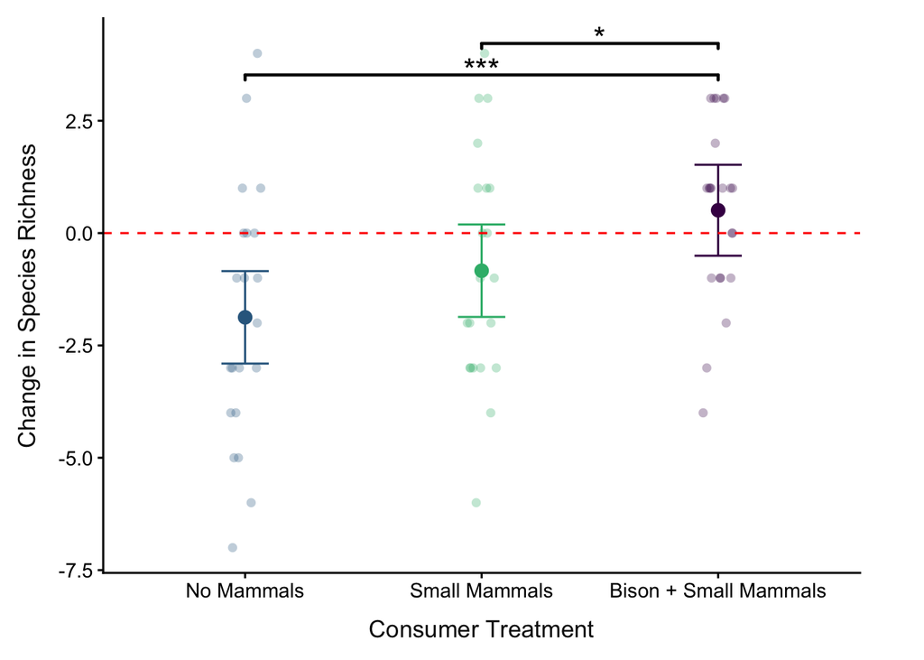

### Fig S2. Delta Richness Management X Herbivory Treatments

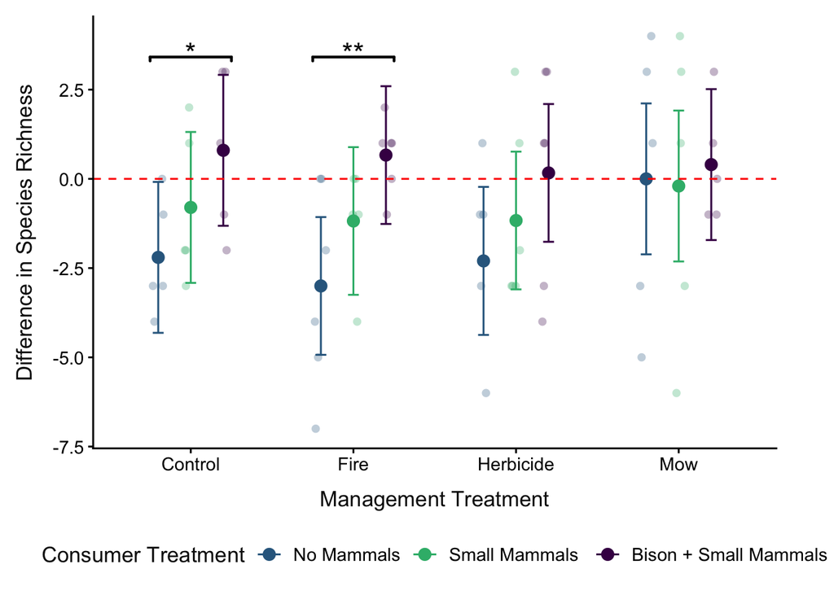

## Shannon and Evenness Metrics

#### Data Cleaning and Set up

Calculate shannon and evennes metrics

Shannon Diversity 2024

#### Fit model for Shannon diversrity

```
##  Family: gaussian  ( identity )
## Formula:          shannon ~ herbivory_trt * management_trt + (1 | block/plot)
## Data: shannon_W24
##
##       AIC       BIC    logLik -2*log(L)  df.resid
##        NA        NA        NA        NA        57
##
## Random effects:
##
## Conditional model:
##  Groups     Name        Variance Std.Dev.
##  plot:block (Intercept) 0.01676  0.1295
##  block      (Intercept) 0.01845  0.1358
##  Residual               0.01676  0.1295
## Number of obs: 72, groups:  plot:block, 72; block, 24
##
## Dispersion estimate for gaussian family (sigma^2): 0.0168
##
## Conditional model:
##                                         Estimate Std. Error z value Pr(>|z|)
## (Intercept)                              1.19889    0.09307  12.881  < 2e-16
## herbivory_trtSX                          0.15794    0.10570   1.494 0.135127
## herbivory_trtSB                          0.46415    0.10570   4.391 1.13e-05
## management_trtfire                       0.48095    0.13162   3.654 0.000258
## management_trtherbicide                  0.28809    0.13162   2.189 0.028617
## management_trtmow                        0.57139    0.13162   4.341 1.42e-05
## herbivory_trtSX:management_trtfire      -0.27140    0.14949  -1.816 0.069442
## herbivory_trtSB:management_trtfire      -0.28949    0.14949  -1.937 0.052801
## herbivory_trtSX:management_trtherbicide  0.01095    0.14949   0.073 0.941602
## herbivory_trtSB:management_trtherbicide -0.41222    0.14949  -2.758 0.005824
## herbivory_trtSX:management_trtmow       -0.13020    0.14949  -0.871 0.383759
## herbivory_trtSB:management_trtmow       -0.41239    0.14949  -2.759 0.005804
##
## (Intercept)                             ***
## herbivory_trtSX
## herbivory_trtSB                         ***
## management_trtfire                      ***
## management_trtherbicide                 *
## management_trtmow                       ***
## herbivory_trtSX:management_trtfire      .
## herbivory_trtSB:management_trtfire      .
## herbivory_trtSX:management_trtherbicide
## herbivory_trtSB:management_trtherbicide **
## herbivory_trtSX:management_trtmow
## herbivory_trtSB:management_trtmow       **
## ---
## Signif. codes:  0 '***' 0.001 '**' 0.01 '*' 0.05 '.' 0.1 ' ' 1
```

```
## Analysis of Deviance Table (Type III Wald chisquare tests)
##
## Response: shannon
##                                Chisq Df Pr(>Chisq)
## (Intercept)                  165.931  1  < 2.2e-16 ***
## herbivory_trt                 19.937  2  4.685e-05 ***
## management_trt                22.120  3  6.160e-05 ***
## herbivory_trt:management_trt  17.557  6   0.007441 **
## ---
## Signif. codes:  0 '***' 0.001 '**' 0.01 '*' 0.05 '.' 0.1 ' ' 1
```

Model summary: Summary of GLMM for shannon diversity in response to management, herbivory and their interaction using data from 2024.

```
##                                       Term Estimate Std. Error z value Pr(>|z|)
## 1                              (Intercept)    1.199      0.093  12.881    0.000
## 2                          herbivory_trtSX    0.158      0.106   1.494    0.135
## 3                          herbivory_trtSB    0.464      0.106   4.391    0.000
## 4                       management_trtfire    0.481      0.132   3.654    0.000
## 5                  management_trtherbicide    0.288      0.132   2.189    0.029
## 6                        management_trtmow    0.571      0.132   4.341    0.000
## 7       herbivory_trtSX:management_trtfire   -0.271      0.149  -1.816    0.069
## 8       herbivory_trtSB:management_trtfire   -0.289      0.149  -1.937    0.053
## 9  herbivory_trtSX:management_trtherbicide    0.011      0.149   0.073    0.942
## 10 herbivory_trtSB:management_trtherbicide   -0.412      0.149  -2.758    0.006
## 11       herbivory_trtSX:management_trtmow   -0.130      0.149  -0.871    0.384
## 12       herbivory_trtSB:management_trtmow   -0.412      0.149  -2.759    0.006
```

Table S2: Type III Wald Chisquare tests

```
##                           Term     Chisq Df      p_value
## 1                  (Intercept) 165.93090  1 5.727432e-38
## 2                herbivory_trt  19.93712  2 4.684994e-05
## 3               management_trt  22.11967  3 6.159590e-05
## 4 herbivory_trt:management_trt  17.55664  6 7.441174e-03
```

Pielou evenness

```
##  Family: gaussian  ( identity )
## Formula:          pielou_E ~ herbivory_trt * management_trt + (1 | block/plot)
## Data: evenness_W24
##
##       AIC       BIC    logLik -2*log(L)  df.resid
##    -131.1     -96.9      80.5    -161.1        57
##
## Random effects:
##
## Conditional model:
##  Groups     Name        Variance Std.Dev.
##  plot:block (Intercept) 0.002187 0.04677
##  block      (Intercept) 0.002800 0.05291
##  Residual               0.002187 0.04677
## Number of obs: 72, groups:  plot:block, 72; block, 24
##
## Dispersion estimate for gaussian family (sigma^2): 0.00219
##
## Conditional model:
##                                         Estimate Std. Error z value Pr(>|z|)
## (Intercept)                              0.68642    0.03458  19.851   <2e-16
## herbivory_trtSX                          0.04159    0.03819   1.089   0.2761
## herbivory_trtSB                          0.06317    0.03819   1.654   0.0981
## management_trtfire                       0.04524    0.04890   0.925   0.3549
## management_trtherbicide                  0.02621    0.04890   0.536   0.5920
## management_trtmow                        0.09809    0.04890   2.006   0.0449
## herbivory_trtSX:management_trtfire      -0.06793    0.05400  -1.258   0.2084
## herbivory_trtSB:management_trtfire      -0.05278    0.05400  -0.977   0.3284
## herbivory_trtSX:management_trtherbicide -0.03204    0.05400  -0.593   0.5529
## herbivory_trtSB:management_trtherbicide -0.06680    0.05400  -1.237   0.2161
## herbivory_trtSX:management_trtmow       -0.07275    0.05400  -1.347   0.1779
## herbivory_trtSB:management_trtmow       -0.08536    0.05400  -1.581   0.1140
##
## (Intercept)                             ***
## herbivory_trtSX
## herbivory_trtSB                         .
## management_trtfire
## management_trtherbicide
## management_trtmow                       *
## herbivory_trtSX:management_trtfire
## herbivory_trtSB:management_trtfire
## herbivory_trtSX:management_trtherbicide
## herbivory_trtSB:management_trtherbicide
## herbivory_trtSX:management_trtmow
## herbivory_trtSB:management_trtmow
## ---
## Signif. codes:  0 '***' 0.001 '**' 0.01 '*' 0.05 '.' 0.1 ' ' 1
```

```
##  Family: beta  ( logit )
## Formula:          pielou_E ~ herbivory_trt * management_trt + (1 | block/plot)
## Data: evenness_W24
##
##       AIC       BIC    logLik -2*log(L)  df.resid
##    -131.8     -97.6      80.9    -161.8        57
##
## Random effects:
##
## Conditional model:
##  Groups     Name        Variance Std.Dev.
##  plot:block (Intercept) 0.04826  0.2197
##  block      (Intercept) 0.06933  0.2633
## Number of obs: 72, groups:  plot:block, 72; block, 24
##
## Dispersion parameter for beta family (): 68.3
##
## Conditional model:
##                                         Estimate Std. Error z value Pr(>|z|)
## (Intercept)                              0.86659    0.17626   4.917  8.8e-07
## herbivory_trtSX                          0.13592    0.20025   0.679   0.4973
## herbivory_trtSB                          0.24536    0.20184   1.216   0.2241
## management_trtfire                       0.17475    0.25122   0.696   0.4867
## management_trtherbicide                  0.05389    0.25039   0.215   0.8296
## management_trtmow                        0.43531    0.25509   1.706   0.0879
## herbivory_trtSX:management_trtfire      -0.29163    0.28392  -1.027   0.3043
## herbivory_trtSB:management_trtfire      -0.21246    0.28676  -0.741   0.4588
## herbivory_trtSX:management_trtherbicide -0.05481    0.28463  -0.193   0.8473
## herbivory_trtSB:management_trtherbicide -0.26091    0.28459  -0.917   0.3593
## herbivory_trtSX:management_trtmow       -0.29589    0.28956  -1.022   0.3068
## herbivory_trtSB:management_trtmow       -0.37006    0.29127  -1.271   0.2039
##
## (Intercept)                             ***
## herbivory_trtSX
## herbivory_trtSB
## management_trtfire
## management_trtherbicide
## management_trtmow                       .
## herbivory_trtSX:management_trtfire
## herbivory_trtSB:management_trtfire
## herbivory_trtSX:management_trtherbicide
## herbivory_trtSB:management_trtherbicide
## herbivory_trtSX:management_trtmow
## herbivory_trtSB:management_trtmow
## ---
## Signif. codes:  0 '***' 0.001 '**' 0.01 '*' 0.05 '.' 0.1 ' ' 1
```

```
##
##  DHARMa nonparametric dispersion test via sd of residuals fitted vs.
##  simulated
##
## data:  simulationOutput
## dispersion = 1.2131, p-value = 0.144
## alternative hypothesis: two.sided
```

```
##
##  DHARMa zero-inflation test via comparison to expected zeros with
##  simulation under H0 = fitted model
##
## data:  simulationOutput
## ratioObsSim = NaN, p-value = 1
## alternative hypothesis: two.sided
```

Same as above. Also beta model reinforces that the single coefficient is non-significant here. Will still use guassian model for results

Table S3: Summary of anova for pielou’s evennes in response to management, herbivory and their interaction using data from 2024.

```
##                           Term     Chisq Df   p_value
## 1                herbivory_trt 0.5993839  2 0.7410465
## 2               management_trt 2.3309659  3 0.5066146
## 3 herbivory_trt:management_trt 4.0446719  6 0.6706310
```

## Comm Comp 2024

### Data Cleaning and Set up for Matrix

Permanova

Table 3: PERMANOVA 2024

```
##                           Term Df Sum_of_Sqs         R2         F p_value
## 1               management_trt  3  4.1157666 0.29964891 10.642816   0.001
## 2                herbivory_trt  2  0.5669353 0.04127580  2.199027   0.001
## 3   Weighted_Grazing_Influence  1  0.2638381 0.01920877  2.046749   0.001
## 4 management_trt:herbivory_trt  6  1.1833062 0.08615075  1.529935   0.001
## 5                     Residual 59  7.6054504 0.55371577        NA      NA
## 6                        Total 71 13.7352966 1.00000000        NA      NA
```

Table S8 permdisp test

```
##        Term Df    Sum Sq    Mean Sq        F N.Perm p_value
## 1    Groups 11 0.2882366 0.02620333 2.271841    999   0.017
## 2 Residuals 60 0.6920376 0.01153396       NA     NA      NA
```

Post Hoc Comparisons

Table S7. Pairwise comparisons of plant community composition for interactive effects in west pasture 2024.

```
##            Comparison Df SumOfSqs      R2       F Pr(>F) sig
## Model...1           7  1  0.19116 0.14632  1.7139  0.076   2
## Model...2           8  1  0.12152 0.08728  0.9563  0.495   1
## Model...3          12  1  0.07754 0.06957  0.7478  0.780   1
## Model...4          13  1  0.13955 0.09903  1.0991  0.356   1
## Model...5          14  1  0.08940 0.07173  0.7727  0.749   1
## Model...6           9  1  0.64350 0.37859  6.0924  0.001   5
## Model...7          10  1  0.67003 0.26419  3.5905  0.004   4
## Model...8          11  1  1.07010 0.37895  6.1019  0.003   4
## Model...9           4  1  0.24090 0.19780  2.4657  0.018   3
## Model...10          5  1  0.20525 0.15209  1.7937  0.096   2
## Model...11          6  1  0.37080 0.20768  2.6212  0.010   4
## Model...12         18  1  0.07766 0.06338  0.6767  0.682   1
## Model...13         22  1  0.20160 0.18073  2.2060  0.034   3
## Model...14         23  1  0.21024 0.15496  1.8337  0.055   2
## Model...15         24  1  0.14363 0.12198  1.3893  0.232   1
## Model...16         19  1  0.98542 0.51363 10.5606  0.002   4
## Model...17         20  1  0.98643 0.36141  5.6595  0.002   4
## Model...18         21  1  1.47171 0.47439  9.0256  0.006   4
## Model...19         15  1  0.30934 0.26594  3.6228  0.009   4
## Model...20         16  1  0.14783 0.12646  1.4476  0.249   1
## Model...21         17  1  0.39713 0.23518  3.0750  0.006   4
## Model...22         31  1  0.18043 0.14439  1.6875  0.166   1
## Model...23         32  1  0.19531 0.13046  1.5003  0.153   1
## Model...24         33  1  0.10335 0.07996  0.8690  0.534   1
## Model...25         28  1  0.89985 0.45257  8.2671  0.004   4
## Model...26         29  1  0.84564 0.30818  4.4546  0.003   4
## Model...27         30  1  1.28531 0.41850  7.1968  0.004   4
## Model...28         25  1  0.24561 0.19573  2.4336  0.055   2
## Model...29         26  1  0.12159 0.09367  1.0334  0.407   1
## Model...30         27  1  0.34137 0.19090  2.3594  0.012   3
## Model...31         52  1  0.04697 0.04212  0.4397  0.868   1
## Model...32         53  1  0.03505 0.03538  0.3668  0.937   1
## Model...33         49  1  0.69842 0.44968  8.1712  0.004   4
## Model...34         50  1  0.78342 0.32002  4.7064  0.001   5
## Model...35         51  1  1.20519 0.43707  7.7643  0.001   5
## Model...36         46  1  0.11672 0.13082  1.5051  0.203   1
## Model...37         47  1  0.13126 0.12221  1.3923  0.194   1
## Model...38         48  1  0.27627 0.18549  2.2773  0.062   2
## Model...39         60  1  0.05482 0.04411  0.4614  0.901   1
```

[output cut: 12 more lines]

```
## Model...52         37  1  0.50515 0.23077  3.0000  0.002   4
## Model...53         38  1  0.70597 0.30998  4.4924  0.005   4
## Model...54         34  1  0.93204 0.53975 11.7272  0.005   4
## Model...55         35  1  0.97175 0.50251 10.1007  0.004   4
## Model...56         36  1  1.03286 0.45596  8.3811  0.006   4
## Model...57         42  1  0.58064 0.19603  2.4383  0.026   3
## Model...58         39  1  0.92863 0.36658  5.7872  0.003   4
## Model...59         40  1  1.00314 0.36148  5.6613  0.004   4
## Model...60         41  1  0.95370 0.31833  4.6699  0.002   4
## Model...61         43  1  1.29856 0.46530  8.7020  0.002   4
## Model...62         44  1  1.45911 0.46786  8.7922  0.004   4
## Model...63         45  1  1.38948 0.41860  7.1999  0.001   5
## Model...64          1  1  0.08055 0.08361  0.9124  0.447   1
## Model...65          2  1  0.09875 0.07888  0.8564  0.508   1
## Model...66          3  1  0.12719 0.08786  0.9633  0.446   1
```

Table S6 Comparisons Comm Comp for Herbivory Main Effects 2024

```
##           Comparison Df SumOfSqs       R2      F Pr(>F) sig
## Model...1          1  1  0.28155 0.035029 1.6698  0.082   2
## Model...2          2  1  0.32099 0.035987 1.7172  0.103   1
## Model...3          3  1  0.24786 0.024229 1.1422  0.298   1
```

Table S6 Comparisons Management main effects Permanova 2024

```
##           Comparison Df SumOfSqs       R2       F Pr(>F) sig
## Model...1          3  1  0.27129 0.067900  2.4768  0.018   1
## Model...2          2  1  2.22530 0.269237 12.5267  0.001   3
## Model...3          1  1  0.56100 0.125486  4.8787  0.001   3
## Model...4          6  1  2.24839 0.282521 13.3882  0.001   3
## Model...5          5  1  0.30188 0.077775  2.8673  0.008   2
## Model...6          4  1  2.62367 0.307976 15.1313  0.001   3
```

#### Data Visualization 2024 West Pasture

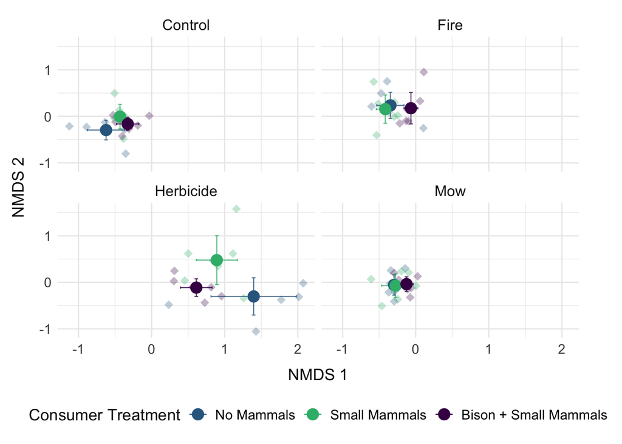

#### Subset Data to run betadispersion tests within each management treatment

Control Subset

Mow Subset

#### Data Visualization Herbicide Distance to Centroid Plot

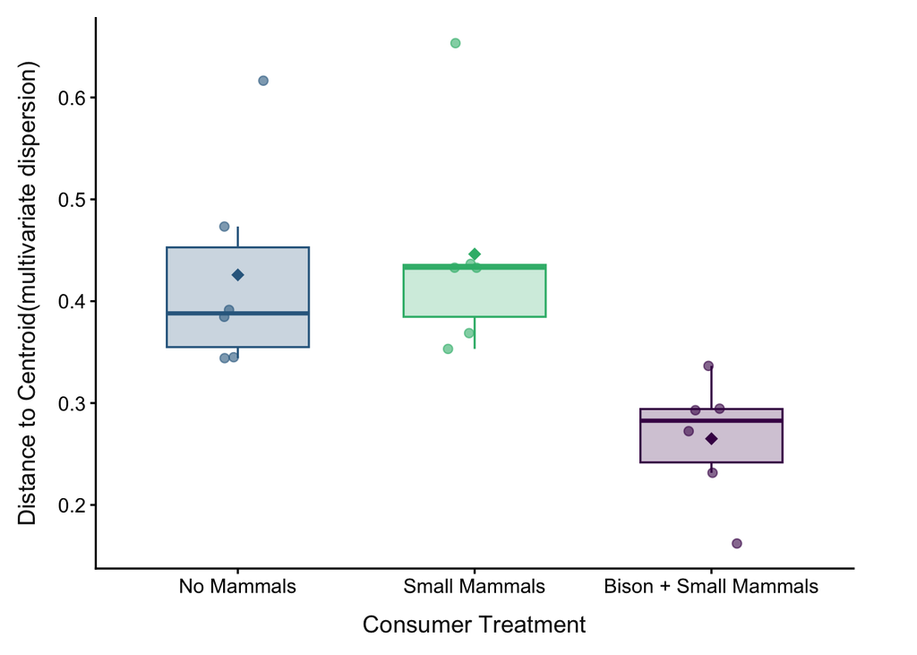